# covid19_CNN_BhargaviRao

###### Objective

The goal of the project is to create a classifier capable of determining the class of the X-ray image

###### Import the necessary libraries

```python
import numpy as np
import pandas as pd
from matplotlib import pyplot as plt
import random
```

```python
import cv2
import numpy as np
import matplotlib.pyplot as plt
%matplotlib inline

from tensorflow.keras import datasets, models, layers, optimizers
from tensorflow.keras.preprocessing.image import ImageDataGenerator
from tensorflow.keras.callbacks import ModelCheckpoint, EarlyStopping
from tensorflow.keras.layers import Conv2D, Flatten, Dense
#from google.colab.patches import cv2_imshow

from tensorflow.keras.models import Sequential          # Sequential groups a linear stack of layers into a tf.keras.Model.
from tensorflow.keras.layers import Conv2D              # This layer creates a convolution kernel that is convolved with the layer input to produce a tensor of outputs.
from tensorflow.keras.layers import MaxPooling2D        # Max pooling operation for 2D spatial data.
from tensorflow.keras.layers import Flatten             # Flattens the input. Does not affect the batch size.
from tensorflow.keras.layers import Dense, Dropout      # Dropout: Applies Dropout to the input.
                                                        # Dense: Just your regular densely-connected NN layer.
import keras
```

```python
%matplotlib inline
```

###### Read the datasets - Train and Test

```python
x_train=np.load('trainimage.npy')
x_test=np.load('testimage.npy')
y_train=pd.read_csv('trainLabels.csv')
y_test=pd.read_csv('testLabels.csv')
```

###### Original Images from the Train dataset

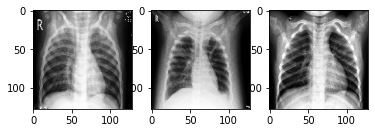

```python
plt.subplot(1, 3, 1); plt.imshow(x_train[2])
plt.subplot(1, 3, 2); plt.imshow(x_train[35])
plt.subplot(1, 3, 3); plt.imshow(x_train[250])
```

###### Original Images from the Test dataset

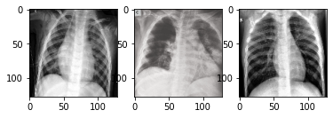

```python
plt.subplot(1, 3, 1); plt.imshow(x_test[2])
plt.subplot(1, 3, 2); plt.imshow(x_test[40])
plt.subplot(1, 3, 3); plt.imshow(x_test[60])
```

###### Data Exploration and Preprocess data

`Steps involved in Pre processing`

1. Value counts checks and % split of each class
2. Conversion of labels to lower case
3. Gaussian blurring - preprocessing train data
4. Gaussian blurring - preprocessing test data
5. Show the images for the preprocessed train and test data
6. Normalize the data

Value counts for the label in Train and Test set

```python
print(y_train.shape)
print(y_train.head(5))
```

```
(251, 1)
             Label
0  Viral Pneumonia
1  Viral Pneumonia
2  Viral Pneumonia
3  Viral Pneumonia
4  Viral Pneumonia
```

```python
round(y_train['Label'].value_counts(normalize=True)*100,2)
```

```
Covid              44.22
Normal             27.89
Viral Pneumonia    27.89
Name: Label, dtype: float64
```

```python
y_train=y_train['Label'].apply(lambda x: x.split()[0].lower())
print(y_train.nunique())
print(y_train.unique())
```

```
3
['viral' 'covid' 'normal']
```

```python
print(y_test.shape)
print(y_test.head(5))
```

```
(66, 1)
             Label
0  Viral Pneumonia
1  Viral Pneumonia
2  Viral Pneumonia
3  Viral Pneumonia
4  Viral Pneumonia
```

```python
y_test=y_test['Label'].apply(lambda x: x.split()[0].lower())

print(y_test.nunique())
print(y_test.unique())
```

```
3
['viral' 'covid' 'normal']
```

```python
num_classes=len(y_test.unique())
print('Number of classes: {}'.format(num_classes))
```

```
Number of classes: 3
```

###### Mapping the labels to the classes

```python
map_dict={'normal':0,'viral':1,'covid':2}
y_train_map=y_train.map(map_dict)
y_test_map=y_test.map(map_dict)

y_train_cat = keras.utils.to_categorical(y_train_map, num_classes)
y_test_cat = keras.utils.to_categorical(y_test_map, num_classes)

print(y_train_cat.shape)
print(y_test_cat.shape)
```

```
(251, 3)
(66, 3)
```

###### Processed images - Gaussian Blurring

`Training data`

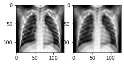

```python
preprocessed_train = []       # Initialize empty list to store the images after pre-processing.

for img in x_train:
    # Use gaussian blur
    blurImg = cv2.GaussianBlur(img, (5, 5), 0)


    preprocessed_train.append(blurImg)        # Append image

    # Show examples

plt.subplot(1, 3, 1); plt.imshow(img)         # Show the original image
plt.subplot(1, 3, 2); plt.imshow(blurImg)     # Blur image

preprocessed_train = np.asarray(preprocessed_train)    # Convert to numpy array.
```

`Testing Data`

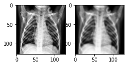

```python
preprocessed_test = []       # Initialize empty list to store the images after pre-processing.

for img in x_test:
    # Use gaussian blur
    blurImg = cv2.GaussianBlur(img, (5, 5), 0)


    preprocessed_test.append(blurImg)        # Append image

    # Show examples

plt.subplot(1, 3, 1); plt.imshow(img)         # Show the original image
plt.subplot(1, 3, 2); plt.imshow(blurImg)     # Blur image

preprocessed_test = np.asarray(preprocessed_test)    # Convert to numpy array.
```

###### Preprocessed Test images

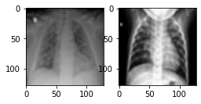

```python
plt.subplot(1, 3, 1); plt.imshow(preprocessed_test[35])
plt.subplot(1, 3, 2); plt.imshow(preprocessed_test[7])
```

###### Preprocessed Train images

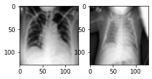

```python
plt.subplot(1, 3, 1); plt.imshow(preprocessed_train[111])
plt.subplot(1, 3, 2); plt.imshow(preprocessed_train[50])
```

###### Normalize image data

```python
preprocessed_train = preprocessed_train / 255
```

```python
preprocessed_test = preprocessed_test / 255
```

# Process the image data

```python
print(preprocessed_train.shape)
print(preprocessed_test.shape)
```

```
(251, 128, 128, 3)
(66, 128, 128, 3)
```

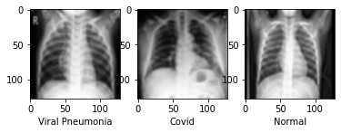

```python
plt.subplot(131)
plt.imshow(preprocessed_train[0])
plt.xlabel('Viral Pneumonia')
plt.subplot(132)
plt.imshow(preprocessed_train[74])
plt.xlabel('Covid')
plt.subplot(133)
plt.imshow(preprocessed_train[189])
plt.xlabel('Normal')
plt.show()
```

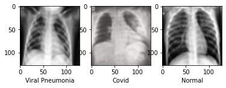

```python
plt.subplot(131)
plt.imshow(preprocessed_test[3])
plt.xlabel('Viral Pneumonia')
plt.subplot(132)
plt.imshow(preprocessed_test[29])
plt.xlabel('Covid')
plt.subplot(133)
plt.imshow(preprocessed_test[60])
plt.xlabel('Normal')
plt.show()
```

###### Reshaping data to compatible shapes

```python
x_train_gray = preprocessed_train.reshape(preprocessed_train.shape[0], 128, 128, 3)
x_test_gray = preprocessed_test.reshape(preprocessed_test.shape[0], 128, 128, 3)
print(x_train_gray.shape)
print(x_test_gray.shape)
```

```
(251, 128, 128, 3)
(66, 128, 128, 3)
```

## Modeling

###### Building Model layers

```python
# specify input dimensions of each image
img_rows, img_cols = 128, 128
input_shape = (img_rows, img_cols, 3)

# batch size, number of classes, epochs
batch_size = 30
epochs = 50
```

```python
print(input_shape)
```

```
(128, 128, 3)
```

### Building CNN:

- Define layers.
- Set optimizer and loss function. (Use Adam optimizer and categorical crossentropy)

`A couple of experimented below :`

1. adding multiple layers and then increasing the conv2D,Maxpooling and dropout layers
2. Using a lesser number of layers

`Lessons learnt`

1. An increase in the number of layers had decreased the accuracy and the model also overfit (The code is hence set to rawNBconvert)
2. Decreasing the number of layers had significantly increased the accuracy

```python
model = Sequential()


model.add(Conv2D(32, kernel_size=(5, 5),
                 activation='relu',strides=1,
                 input_shape=input_shape))

model.add(Conv2D(64, kernel_size=(5, 5),strides=1,
                 activation='relu'))
model.add(MaxPooling2D(pool_size=(2, 2)))
model.add(Dropout(0.25))


model.add(Flatten())
model.add(Dense(128, activation='relu'))
model.add(Dropout(0.25))


model.add(Dense(num_classes, activation='softmax'))


model.summary()
```

```
Model: "sequential"
_________________________________________________________________
Layer (type)                 Output Shape              Param #
=================================================================
conv2d (Conv2D)              (None, 124, 124, 32)      2432
_________________________________________________________________
conv2d_1 (Conv2D)            (None, 120, 120, 64)      51264
_________________________________________________________________
max_pooling2d (MaxPooling2D) (None, 60, 60, 64)        0
_________________________________________________________________
dropout (Dropout)            (None, 60, 60, 64)        0
_________________________________________________________________
flatten (Flatten)            (None, 230400)            0
_________________________________________________________________
dense (Dense)                (None, 128)               29491328
_________________________________________________________________
dropout_1 (Dropout)          (None, 128)               0
_________________________________________________________________
dense_1 (Dense)              (None, 3)                 387
=================================================================
Total params: 29,545,411
Trainable params: 29,545,411
Non-trainable params: 0
_________________________________________________________________
```

```python
# initiate Adam optimizer
opt = optimizers.Adam(learning_rate=0.001, beta_1=0.9, beta_2=0.999, epsilon=1e-08)
```

```python
model.compile(loss='categorical_crossentropy',
              optimizer=opt,
              metrics=['accuracy'])
```

```python
model.summary()
```

```
Model: "sequential"
_________________________________________________________________
Layer (type)                 Output Shape              Param #
=================================================================
conv2d (Conv2D)              (None, 124, 124, 32)      2432
_________________________________________________________________
conv2d_1 (Conv2D)            (None, 120, 120, 64)      51264
_________________________________________________________________
max_pooling2d (MaxPooling2D) (None, 60, 60, 64)        0
_________________________________________________________________
dropout (Dropout)            (None, 60, 60, 64)        0
_________________________________________________________________
flatten (Flatten)            (None, 230400)            0
_________________________________________________________________
dense (Dense)                (None, 128)               29491328
_________________________________________________________________
dropout_1 (Dropout)          (None, 128)               0
_________________________________________________________________
dense_1 (Dense)              (None, 3)                 387
=================================================================
Total params: 29,545,411
Trainable params: 29,545,411
Non-trainable params: 0
_________________________________________________________________
```